# Hydrologic models and the questions they answer

An overview of hydrologic modeling

HWRS 564a · Fall 2026 · Andrew Bennett

One watershed, three modeling questions

Assume a mountain watershed drains toward a city in southern Arizona

Road warning

A short, intense storm is building. Should we warn drivers at a low road crossing?

Seasonal supply

How much water will this season deliver, including snow from the upper slopes?

Pumping impact

How would more groundwater pumping affect a connected stream over decades?

Discussion question

For each question, name a target variable and its time scale.

2

Purpose decides the model

Purpose

The question and the decision it serves

→

Behavior

Targets, scales and required accuracy

→

Representation

Stores, fluxes, space and time

→

Tests

Evidence that resembles the use

By the end of this lecture you should be able to:

1. Classify a model on process, space, time and uncertainty
2. Choose a test that matches the intended use
3. Separate a residual from its possible causes
4. Say what an ensemble includes, and what it leaves out

3

The water cycle contains many processes!

[figure not shown]

Draw the boundary based on the purpose first

1. Circle the part of the system your question needs
2. Mark its stores, fluxes, inputs and outputs
3. Decide whether withdrawals, reservoirs, or other human impacts need to be represented

4

USGS Water Science School and VizLab (2022), cropped; public domain

A conceptual account comes before equations

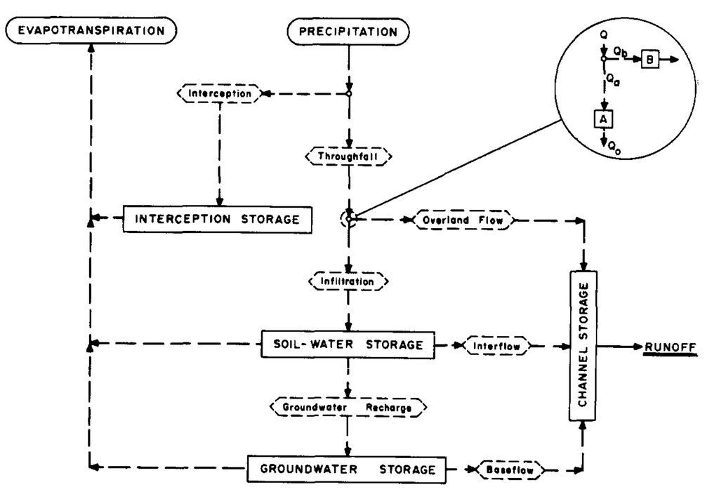

Conceptual account

↓

Mathematical relationships

↓

Implementation in code

↓

Application with real data

5

Freeze and Harlan (1969), Fig. 2, p. 242

States carry memory; fluxes move water

State variable

Flux

Units

An amount: mm of water, m of head

A rate: mm/day, m³/s

Defined

At an instant

Over an interval

Needs

An initial condition

A closure relation

Examples

SWE, soil water, aquifer storage

P, ET, infiltration, recharge, runoff

Measured by

Snow pillow, soil probe, well

Stream gauge, rain gauge, flux tower

States change only through fluxes, and many fluxes depend on states (q = kS). For head, a storage–head relation links its change to the water balance.

6

Chapter sections 2.1–2.3

A model has states, inputs, parameters and outputs

State evolution

[figure not shown]

Observation

[figure not shown]

For one reservoir: x = S, u = effective input, θ = k, and the output ŷ = q = kS.

x

States

Carry memory: SWE, soil water, heads

u

Inputs

Forcing and boundary conditions from outside

θ

Parameters

Set the relationships; fixed during a run

M

Structure

Which stores and fluxes exist at all

x₀

Initial conditions

Where each store starts; spin-up matters

h

Observation operator

Maps the model to what a sensor sees

7

Chapter equation (2), section 2.2

Conservation needs flux relations

Conservation laws usually hold

[figure not shown]

Storage, precipitation, evapotranspiration, runoff, groundwater exchange and net withdrawal, all as depth per time

Closure of conservation is a choice

[figure not shown]

**S** storage (mm) · **k** drainage parameter (day⁻¹), drainage time 1/k · **f(T, S)** an ET function of temperature and storage

**One day, with E folded into a net effective input u:**

[figure not shown]

Storage after one day, S₁

25.438 mm

Integrated outflow over one day

4.562 mm

S₀ and S₁ are states, in mm. The outflow is a flux, here summed over the day in mm.

8

Chapter equations (1), (3) and (4); solver comparison on slide 36

Process representation is one axis

Empirical or learned

Relations learned from observations

*Methods: unit hydrograph, regression, LSTM*

**Watch for:** transfer to new conditions

Conceptual storage

A few stores and fluxes as hypotheses

*Model families: GR4J, HBV, Sacramento*

**Watch for:** unidentifiable parameters

Detailed process

Conservation laws with explicit properties

*Equations: Darcy, Richards, energy balance*

**Watch for:** uncertain properties and closures

9

After Refsgaard (1996); Clark et al. (2017)

10

Original diagram for HWRS 564a

Spatial organization is a separate axis

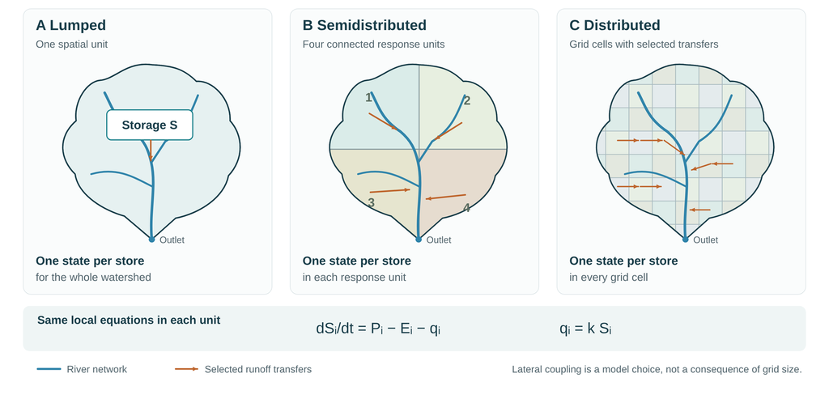

Model classification 1: Engineering preferred models

Software

Primary domain

Process and spatial representation

Typical output

MODFLOW

Groundwater

Darcy flow and mass conservation on 3D structured or unstructured grids

Heads, drawdown, budgets, stream–aquifer exchange

HYDRUS

Vadose zone

Richards equation, heat and solute transport; 1D to 3D finite elements

Infiltration, root-zone moisture, drainage, leaching

HEC-HMS

Catchment rainfall–runoff

Selectable loss, transform, baseflow and routing methods; subbasin network

Event and continuous hydrographs, design floods

HEC-RAS

River and floodplain hydraulics

1D steady and 1D/2D unsteady flow on cross-sections and 2D meshes

Water level, inundation depth and extent, velocity

For the road warning, HEC-HMS can make the hydrograph; turning flow into depth at the crossing is a hydraulic step. Often, multiple models are coupled together into a "modeling chain"

11

Official documentation: USGS, PC-Progress, USACE HEC

Model classification 2: Research focused models

Software

Primary domain

Process and spatial representation

Typical output

VIC

Macroscale land surface

Water and energy balance, subgrid infiltration; independent cells, separate routing

Regional runoff, ET, snow, soil moisture

Noah-MP

Land surface

Vegetation, snow and soil exchanges; alternative options; vertical columns

Surface fluxes, ET, soil moisture, generated runoff

SUMMA

Modeling framework

Common conservation equations with selectable flux options and lateral connectivity

Controlled tests of process hypotheses

ParFlow

Integrated surface–subsurface

3D Richards subsurface flow coupled to overland flow; CLM adds land-surface exchange

Pressure, saturation, water table, runoff

A grid does not imply lateral groundwater flow: standard VIC cells are independent, while ParFlow couples them explicitly.

12

Official documentation: VIC, NCAR RAL, SUMMA, ParFlow

Time and prediction design are separate choices

Temporal design

- Event or continuous
- Steady or transient
- Time step is not the reporting interval

Uncertainty treatment

- One deterministic run
- Stochastic model components
- Ensemble of deterministic runs

Kind of experiment

- Reconstruction with observed forcing
- Forecast at an issue time
- Conditional scenario

A learned model can carry memory and still predict deterministically. A fine grid settles none of these choices.

13

Chapter sections 1.1 and 3.5

Classify before you choose

MODFLOW 6

HYDRUS

HEC-HMS

HEC-RAS

VIC

Noah-MP

SUMMA

ParFlow

LSTM

Discussion questions:

1. Which could directly answer the pumping question?
2. Which needs another component to turn runoff into depth at the crossing?
3. Which lets us vary model structure systematically?

For your pick, state the configuration and its process, spatial, temporal and uncertainty choices, not just the name.

15

Process, observation and model scales differ

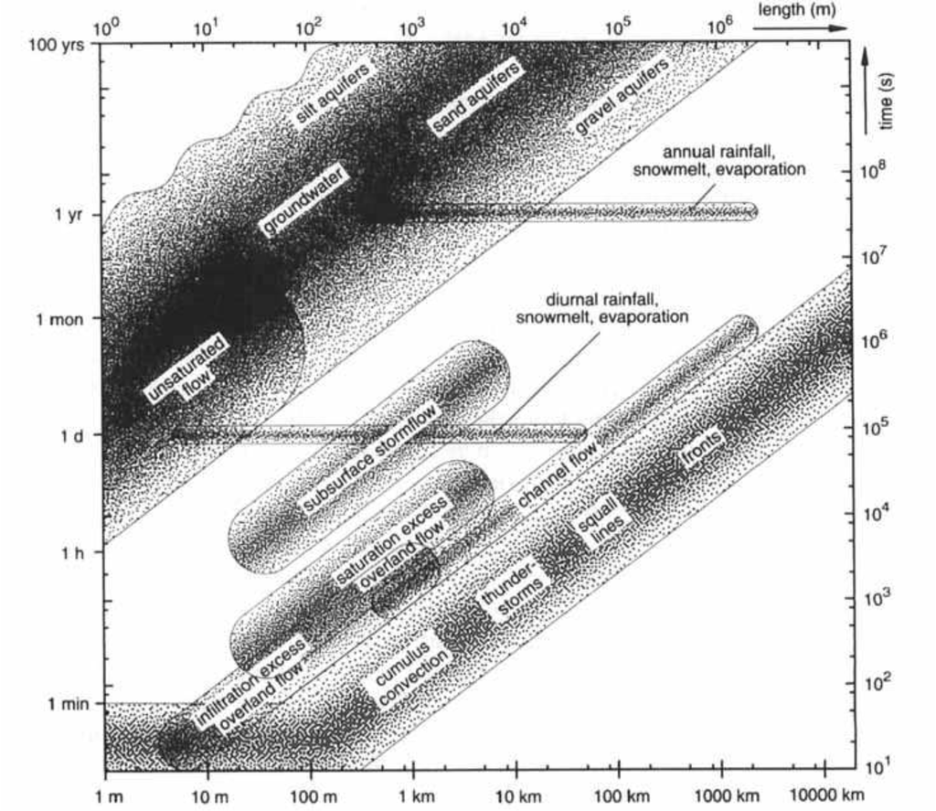

**Process:** characteristic length and time

**Observation:** extent, spacing and support

**Model:** domain, element size and time step

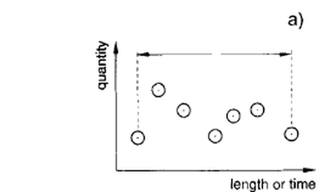

(a) Extent

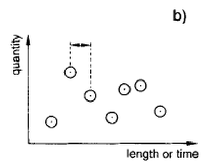

(b) Spacing

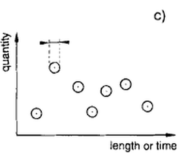

(c) Support

Interpolating hourly rainfall to minutes adds values, not information.

16

Blöschl and Sivapalan (1995), Figs. 2 and 4, pp. 253 and 256

Scale effects emerge even in the simplest of cases

Rainfall p = 30 mm/h on two equal areas. Local runoff r = max(0, p − f), where f is infiltration capacity.

Compute locally, then average

Area 1

f = 10 mm/h

r = ?

Area 2

f = 50 mm/h

r = ?

Area-average runoff = ?

Average capacity first

One mean area

f̄ = 30 mm/h

r = ?

Runoff = ?

Your turn · 1 minute

Compute both columns. Predict first: will averaging the capacity change the answer?

17

Original teaching calculation (chapter section 4.1)

Scale effects emerge even in the simplest of cases

Rainfall p = 30 mm/h on two equal areas. Local runoff r = max(0, p − f), where f is infiltration capacity.

Compute locally, then average

Area 1

f = 10 mm/h

r = 20 mm/h

Area 2

f = 50 mm/h

r = 0 mm/h

Area-average runoff = 10 mm/h

Average capacity first

One mean area

f̄ = 30 mm/h

r = 0 mm/h

Runoff = 0 mm/h

[figure not shown]

This motivates effective parameterization. It does not show that lumped models always fail.

18

Original teaching calculation (chapter section 4.1)

Increases in computing opened doors without settling adequacy

Period or landmark

Opportunity

Question that remains

1932 · Unit hydrograph

Analytical, empirical response methods

Which assumptions hold for this use?

1960s · Stanford Watershed Model

Continuous accounting of linked stores

How to constrain parameters and initial states?

1969 · Freeze and Harlan

Couple physical component equations

Are equations, inputs and computing adequate?

Theme · Optimization and ensembles

Explore parameters, objectives, uncertainty

What does a good fit actually identify?

2015 · SUMMA; 2019 · an LSTM landmark

Compare hypotheses; learn across basins

What causes improvement, and where does it transfer?

Each advance answered one problem and exposed another. These approaches still coexist and are used for various use cases. The 1969 Freeze & Harlan paper still reads closely to how modern models are developed.

19

Refsgaard (1996); Clark et al. (2015, 2017); Kratzert et al. (2019); Beven (2025)

Equations, data, and computation stay coupled

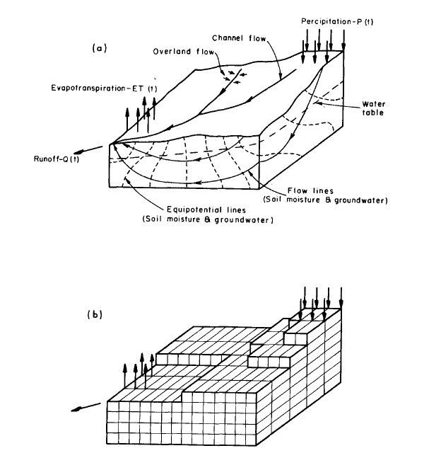

The blueprint’s questions, still open

1

Are suitable equations available?

2

Can the required properties and inputs be estimated?

3

Can they be solved at a cost that permits meaningful analysis?

A fine spatial grid is not proof of realism: what do the nodes represent, and which boundaries are left unspecified?

20

Freeze and Harlan (1969), Fig. 3, p. 243; questions after Clark et al. (2017)

Land surface models grew by adding processes

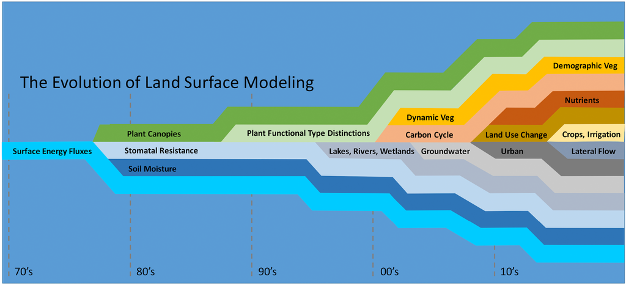

Began as energy-flux boundary conditions for climate models

Soil water: bucket, then 1D Richards, then 3D variably saturated flow

Added piecemeal and differently in each model

No one person now understands every part of a modern land surface model.

21

Fisher and Koven (2020), Fig. 1, JAMES, CC BY

Three grand challenges for land surface models

Process complexity

Modular designs that let each process be detailed, simplified or held fixed

Heterogeneity

Even 1–10 km cells hide forest gaps and microtopography; subgrid tiles split the cell

Parameter dynamics

Many parameters; equally good fits can diverge under novel conditions

The same lessons as a catchment model, modular structure, scale and equifinality, at Earth-system scope.

22

Fisher and Koven (2020), JAMES 12, e2018MS001453

A workflow keeps returning to purpose and data

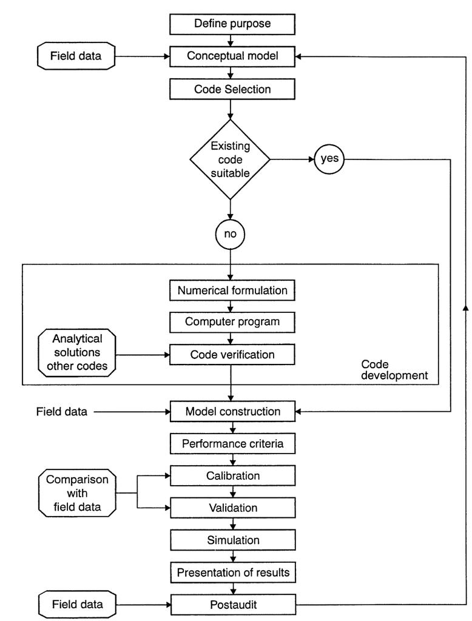

1. **Define purpose** and the evidence that would count
2. **Inspect data,** then draw the conceptual model
3. **Choose candidates,** including a simple benchmark
4. **Verify the code,** then calibrate
5. **Evaluate on held-out data** and diagnose failures
6. **Quantify uncertainty,** use the result, post-audit

In practice

- Align rainfall and discharge intervals; convert m³/s to mm/day with catchment area
- Keep missing and zero flow distinct; set test data aside before fitting any transform
- Benchmark: persistence for warnings, a seasonal reference for supply
- Archive data, code and configuration versions

A failed test sends you back: new data, new boundaries or a new concept.

23

Refsgaard (1996), Fig. 3, p. 24, after Anderson and Woessner (1992)

Calibration is one part of credibility

Verification

Does the code solve the stated equations?

Balances, convergence, analytical cases

Calibration

Which values fit the chosen evidence?

Sensitive is not the same as identifiable

Independent test

Does it hold where it will be used?

Data kept out of fitting, tuning and selection

Verify before you interpret a calibrated parameter. Judge credibility only on data kept out of fitting.

24

Chapter section 6.4; Refsgaard (1996)

25

Original diagram for HWRS 564a

A useful test resembles the intended use

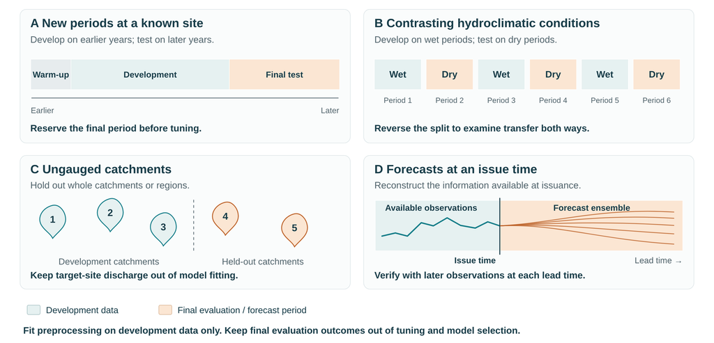

Choose the metric from the purpose

Road warning

Peak magnitude, arrival time, hits and false alarms at the warning stage, by lead time

Seasonal supply

Accumulated volume, seasonal timing, reliability of meeting demand

Pumping impact

Head residuals at wells kept out of calibration; stream depletion

More metrics on the same discharge series are not a new, independent constraint.

26

Chapter sections 6.5–7; Beven (2025)

A metric/score needs a reference and a purpose

[figure not shown]

q observed flow · q̂ simulated flow · q̄ mean observed flow over the evaluation period · sums run over time steps t

Interpreting NSE

- 1: a perfect fit
- 0: no better than the observed mean
- Below 0: worse than that mean
- Undefined if observed flow never varies

Shortcomings

- Squared errors weight high flows
- Timing, low-flow and seasonal errors
- The mean is not a forecast you could have issued

Compare with a benchmark you could have issued: persistence, a seasonal reference or a simple model.

27

Nash and Sutcliffe (1970); chapter equation (7); other scores on slide 38

Nine parameter sets pass the output tests

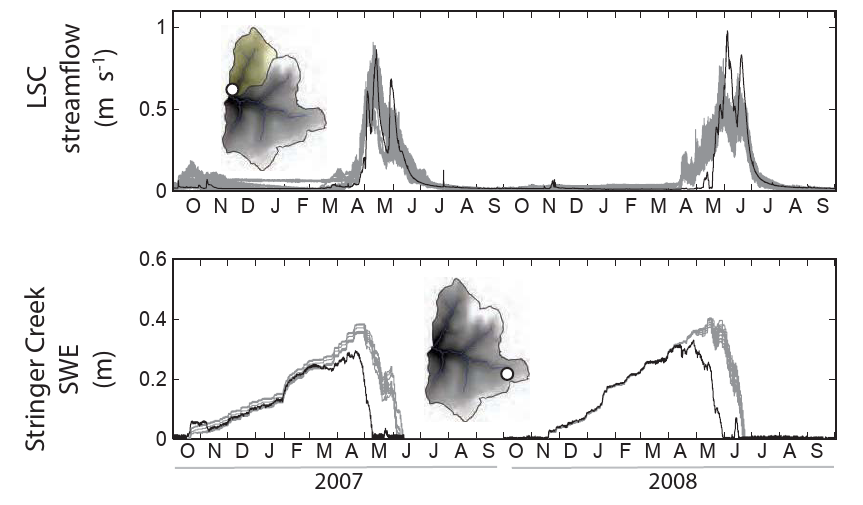

Lower Stringer Creek (calibration gauge) streamflow and Stringer Creek SWE. Water year 2007 = evaluation, 2008 = calibration.

10,000

parameter sets tested

→

9

retained

Gray: the nine retained sets. Black: observations.

**Equifinality:** different parameter sets fit the chosen data under the chosen criteria.

Your turn

What do these hydrographs establish about subsurface storage?

28

Kelleher, McGlynn and Wagener (2017), Fig. 7 (cropped), p. 3336, CC BY 3.0

The same nine sets disagree about the water table

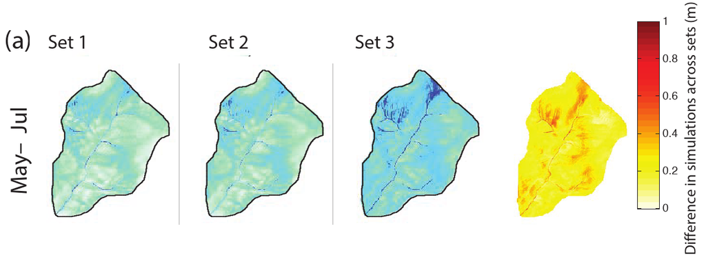

>0.2 m

range across all nine sets over more than 64% of the catchment, May–July

Left: three of the nine sets; water-table depth from −1 m (bedrock, pale) to 0 m (surface, dark blue). Right: cell-wise range across all nine sets. Model predictions, not observed maps.

Is this fixable?

Propose one measurement that would separate these predictions. State its spatial and temporal support.

29

Kelleher, McGlynn and Wagener (2017), Fig. 9 (cropped), p. 3338, CC BY 3.0

Errors do not name their source, and it is difficult to find

Source

Hydrologic example

Forcing

A gauge misses a convective storm

Evaluation data

A flood peak from an extrapolated rating curve

Parameters

Several soil capacities fit the same hydrograph

Structure

Missing channel losses or groundwater exchange

Initial and boundary

Unknown antecedent soil water or edge heads

Numerics

A time step that skips a runoff threshold

Future conditions

Unknown pumping, land cover or climate

Your turn

The simulated flood peak is too low. Name three possible causes, and one check that would tell them apart before recalibrating.

Tuning a soil parameter can fix the fit while hiding a rainfall error.

30

Chapter section 8; Beven (2025)

An ensemble shows only the sources it varies

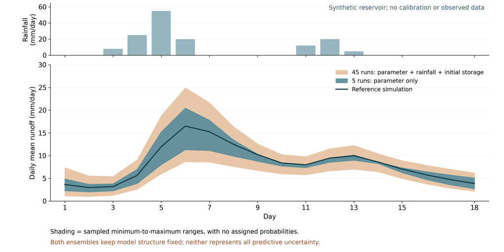

**5 runs** vary the drainage parameter k only

**45 runs** also vary rainfall and initial storage

Both keep one structure. Shading is a sampled range, not a probability.

**Coverage:** does a 90% interval hold the observation about 90% of the time?

**Sharpness:** how narrow is it? A wide band covers easily and helps little.

31

Original synthetic calculation (chapter section 8.3, Fig. 9)

Institutional legacy shapes model choice

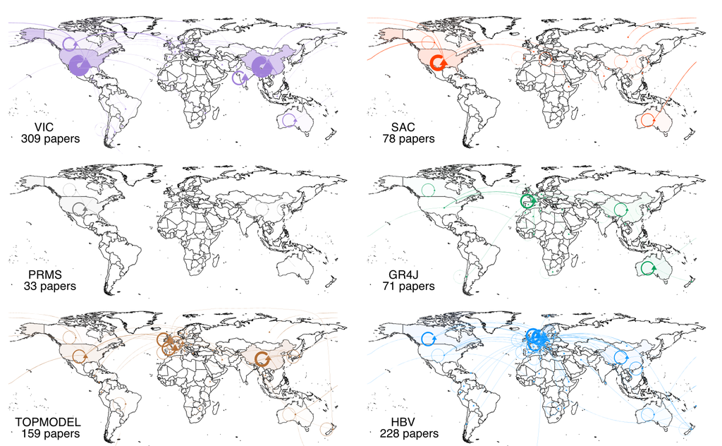

≈74%

average share of an institute’s papers that used its favorite model

Fig. 2c: 810 papers from 70 institutes with at least five papers, seven rainfall–runoff models. The maps (Fig. 1) show geography of use, not skill.

Evidence of attachment, not proof that the choices were unsuitable.

32

Addor and Melsen (2019): maps Fig. 1, p. 381; statistic Fig. 2c, p. 382

Back to the watershed: three worked choices

Road warning

Target

Stage at the crossing, hours ahead

Candidate

Event-resolving runoff with antecedent wetness, plus a rating or hydraulic model

Essential data

Radar and gauge rainfall; stage at the crossing

Independent test

Hindcast past storms with issue-time data only

Seasonal supply

Target

Seasonal inflow volume and timing

Candidate

Continuous model with snow, ET and carryover storage, run with a forcing ensemble

Essential data

Snow water equivalent; long inflow record

Independent test

Held-out wet and dry years

Pumping impact

Target

Heads and stream depletion, years to decades

Candidate

Transient groundwater model with aquifer geometry, boundaries and stream exchange

Essential data

Well heads; streamflow gains and losses

Independent test

Wells kept out of calibration; scenarios for pumping and recharge

33

Chapter section 9

Conclusions

1 · Purpose comes first

The question sets the target, scales and test before any model is named.

2 · Axes are separate

Process, space, time and uncertainty are independent choices. A label or a grid settles none of them.

3 · Scale changes answers

Thresholds make averaging consequential. Resolution must serve a requirement you can test.

4 · Fit is not adequacy

Verification, calibration and independent tests answer different questions. Good hydrographs can hide divergent internal states.

5 · Uncertainty has a scope

A residual does not name its cause, and an ensemble shows only the sources it varies.

6 · Defend the choice

Link representation, data and tests to the question. Familiarity is a reason to state, not evidence.

Treat every model as a set of hypotheses you can test. This includes not just the model structure, but also the data, parameters, and calibration methods used.

34

Reading: full chapter; section 7.1 with Kelleher et al. (2017)

Sources

- Abbott and Refsgaard, eds. (1996). *Distributed Hydrological Modelling.* Kluwer.
- Addor and Melsen (2019). *Water Resources Research* 55, 378–390.
- Beven (2025). *WIREs Water* 12, e1761.
- Blöschl and Sivapalan (1995). *Hydrological Processes* 9, 251–290.
- Clark et al. (2015). *Water Resources Research* 51, 2498–2514.
- Clark et al. (2017). *HESS* 21, 3427–3440.
- Fisher and Koven (2020). *JAMES* 12, e2018MS001453.
- Freeze and Harlan (1969). *Journal of Hydrology* 9, 237–258.
- Gupta et al. (2009). *Journal of Hydrology* 377, 80–91.
- Kelleher, McGlynn and Wagener (2017). *HESS* 21, 3325–3352.
- Knoben, Freer and Woods (2019). *HESS* 23, 4323–4331.
- Kratzert et al. (2019). *HESS* 23, 5089–5110.
- Nash and Sutcliffe (1970). *Journal of Hydrology* 10, 282–290.
- Peters-Lidard et al. (2017). *HESS* 21, 3701–3713.
- Razavi and Tolson (2013). *Water Resources Research* 49, 8418–8431.
- Refsgaard (1996). In Abbott and Refsgaard, eds., pp. 17–39.
- USGS (2022). *The Water Cycle.* Water Science School and VizLab.

Model descriptions on slides 11–12 and 40–41 follow official developer documentation (links in those slides’ notes). Publisher figures keep their original rights and are shown for teaching. Kelleher et al. (2017) is CC BY 3.0; the USGS diagram is public domain. Check permissions before distributing the deck publicly.

35

Backup

Two solvers, one day, the same reservoir

[figure not shown]

Solver

Storage after one day

Outflow over the day

Exact update

25.438 mm

4.562 mm

Forward Euler

26 mm

4 mm

Both close their discrete balance. Tuning k can hide the solver error; it does not remove it.

36

Chapter equations (3) and (4)

Backup

Is a short calibration period representative?

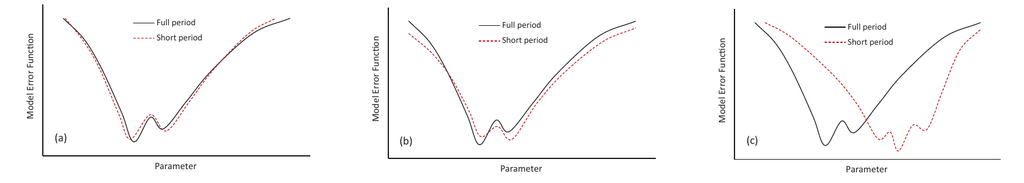

Does the short-period optimum match the full-record optimum? (a) yes, (b) nearly, (c) no.

These curves are about calibration efficiency and representativeness. Neither period here is a held-out validation test.

37

Razavi and Tolson (2013), Fig. 1, p. 8420 (conceptual curves)

Backup

Other scores and what they reward

[figure not shown]

r correlation of simulated and observed flow · α ratio of standard deviations · β ratio of means

Score

What it rewards

What it can hide

KGE

r near 1, and α and β near 1

Which component failed, if reported alone

Percent bias

The right total volume

Timing and hydrograph shape

NSE on log flows

Fit at low flows

Peaks; zero flows need a treatment that changes the score

Peak and timing error

Event magnitude and arrival

Volumes between events

38

Gupta et al. (2009); Knoben, Freer and Woods (2019)

Backup

Stringer Creek: the full figures

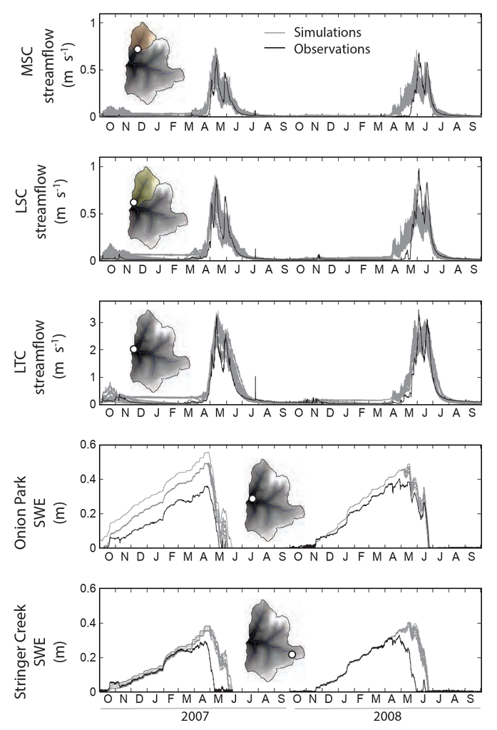

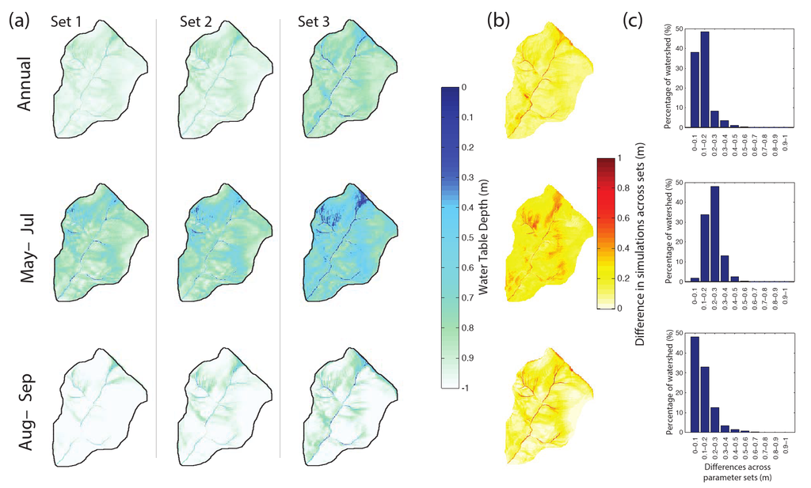

39

Kelleher, McGlynn and Wagener (2017), Figs. 7 and 9, CC BY 3.0

Backup

More named models: catchment and watershed

Software

Primary domain

Process and spatial representation

Typical output

HBV-light

Conceptual catchment

Snow, soil-water, response and routing routines; elevation and vegetation zones

Daily runoff, snow response

GR4J (airGR)

Parsimonious rainfall–runoff

Four-parameter daily storage and routing model, usually lumped

Daily discharge, benchmarks

PRMS

Watershed water balance

Modular water and energy accounting on hydrologic response units

Snow, ET, runoff, streamflow

SWAT+

Watershed management

Water balance with conceptual parameterizations and land-management routines on HRUs

Runoff, sediment, nutrient loads

40

Official documentation: Univ. of Zurich, airGR, USGS, Texas A&M

Backup

More named models: distributed, coupled and learned

Software

Primary domain

Process and spatial representation

Typical output

DHSVM

Distributed watershed

Water and energy accounting on a fine terrain grid with lateral flow

Snow, spatial wetness, streamflow

WRF-Hydro

Coupling and routing framework

Land model, often Noah-MP, plus terrain, subsurface and channel routing

Forecast streamflow, spatial runoff

MIKE SHE

Integrated catchment

Coupled surface, unsaturated, saturated and channel processes

Recharge, groundwater–river exchange

NeuralHydrology

Learned prediction framework

Configurable networks, including LSTMs; catchment time series, no spatial grid implied

Streamflow; regional generalization tests

41

Official documentation: PNNL, NCAR, DHI, NeuralHydrology